# Lab 5 - Spatial Dependence

ECOL 620 - Applications in Landscape Ecology

George Woolsey

09 March, 2023

# Setup

```r
# bread-and-butter
library(tidyverse)
library(lubridate)
library(viridis)
library(scales)
library(latex2exp)
# visualization
library(kableExtra)
library(ggtext)
# spatial analysis
library(terra)
library(stars)
library(pgirmess) #for simple correlograms
library(ncf)  #for spline correlograms
library(spdep)  #for general correlograms
library(gstat)  #for variograms/kriging
# set seed
set.seed(11)
```

# Rules

1. Using the provided R Markdown template, answer all questions and show your R code where necessary. Note, some questions are just plain text written answers.
2. Complete your assignment using the R markdown file and submit individual assignments to Canvas. Knit your script and submit an .html file on Canvas. Please use the following naming convention: lab5_firstname_lastname.html (ex. lab5_kyle_horton.html). Note, we will not grade labs in any other format.

# Part 1: Short Answer

## Question 1

Describe the difference in the use of Moran’s I and Ripley’s K (or L-function). (3 pts)

Ripley’s K and the standardized L function quantify the aggregation of points on a landscape within a circular radius from a given point to determine if there is a significant difference between the observed pattern of points and a completely random distribution of points (Complete Spatial Randomness [CSR]). Moran’s I is used to quantify spatial dependence, or the similarity of a variable as a function of spatial location and/or geographic distance ([Fletcher & Fortin 2018](https://link.springer.com/book/10.1007/978-3-030-01989-1)). Moran’s I is a Pearson’s coefficient (range -1 to 1) for one variable against itself (autocorrelation) according to increasing distances among sampling locations.

## Question 2

Describe the difference between a correlogram and semivariogram. How do the scales compare? (3 pts)

Correlograms and semivariograms are complementary approaches used to quantify spatial dependence. Correlograms plot a correlation coefficient such as Moran’s I (autocorrelation of one variable) as a function of distance. Semivariograms plot semivariance (a “stabilized” measure of variance) as a function of distance. A correlation coefficient, used in a correlogram, is constrained between -1 (perfect negative correlation) and 1 (perfect positive correlation) with values close to 0 indicating weak correlation. Semivariance, used in a semivariogrm, is in the same units as the data (e.g. meters) with small values (close to 0) indicating strong spatial covariance and large values indicating less spatial covariance (i.e. weak or no spatial pattern).

## Question 3

Label the following semivariogram. (4 pts)

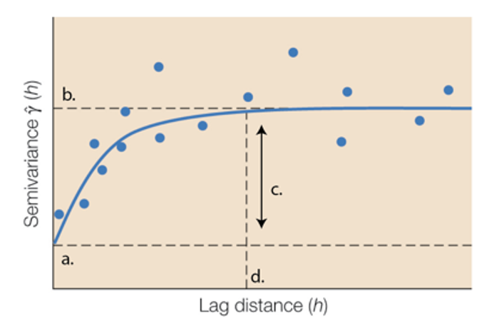

# Part 2: Cactus data

## Question 4: Correlogram (Moran’s I)

Generate a single plot containing the values from the two methods employed to generate correlograms (`pgirmess::correlog` and `ncf`, e.g., see figure 5.5a from Fletcher and Fortin). Also see the example of Canvas (Question 4 plot). Be sure to use 2/3rd maximum distance to restrict the values. Color the points based on p-value significance (e.g., red<0.05, black>0.05). At what distance(s) do you see spatial autocorrelation? Use ggplot to generate the graphic. (7 pts).

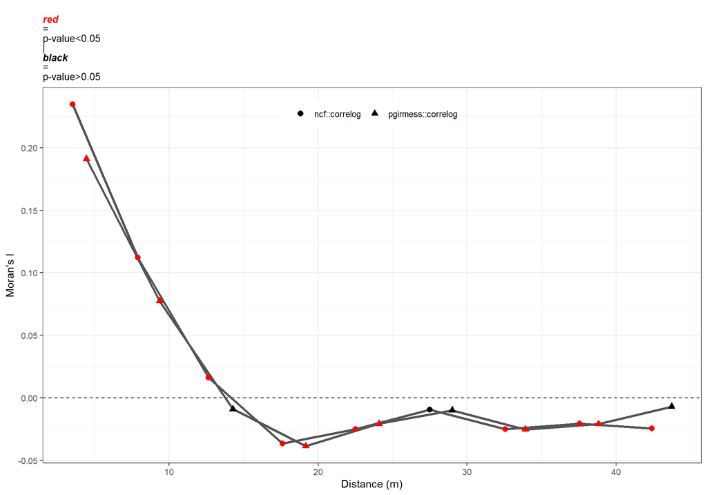

```r
# load data
cactus_df <- read.csv('../data/cactus_matrix.csv', header=T)
#  Computes Moran's coefficients on distance classes
# pgirmess::correlog
  cactus_morans_temp <- pgirmess::correlog(
      coords = cactus_df %>% dplyr::select(x, y)
      , z = cactus_df$Height
      , method = "Moran"
      , nbclass = 14
      , alternative = "two.sided"
    ) %>%
    as.data.frame() %>%
    dplyr::mutate(method = "pgirmess::correlog")
# ncf::correlog
  cactus_morans_full <- ncf::correlog(
      x = cactus_df$x
      , y = cactus_df$y
      , z = cactus_df$Height
      , increment = 5
      , resamp = 99
    )[1:5] %>%
    as.data.frame() %>%
    dplyr::mutate(method = "ncf::correlog") %>%
    dplyr::rename(
      dist.class = mean.of.class
      , coef = correlation
      , p.value = p
    ) %>%
    dplyr::select(names(cactus_morans_temp)) %>%
    # combine with alternative method
    rbind(cactus_morans_temp) %>%
    dplyr::mutate(
      signif = ordered(
        ifelse(p.value <= 0.05, 1, 0)
        , levels = c(0, 1)
        , labels = c("p-value>0.05", "p-value<0.05")
      )
    )
remove(cactus_morans_temp)
#Maximum distance to consider in correlogram/variogram (~1/2 to 2/3 total dist)
maxdist <- max(cactus_morans_full$dist.class)*(2/3)
# plot
ggplot(
    data = cactus_morans_full %>%
      dplyr::filter(dist.class <= maxdist)
    , mapping = aes(x = dist.class, y = coef, group = method)
  ) +
  geom_hline(mapping = aes(yintercept = 0), color = "gray11", linetype = "dashed") +
  geom_line(color = "gray33", size = 1.2) +
  geom_point(mapping = aes(color = signif, shape = method), size = 2.5) +
  scale_color_manual(values = c("black", "red")) +
  labs(
    subtitle = "<span>
        <span style='color:red;'><b><i>red</i></b></span> = p-value<0.05 |
        <span style='color:black;'><b><i>black</i></b></span> = p-value>0.05
        </span>"
    , y = "Moran's I"
    , x = "Distance (m)"
  ) +
  theme_bw() +
  theme(
    plot.subtitle = ggtext::element_markdown(size = 10)
    , legend.position = c(0.5, 0.93)
    , legend.direction = "horizontal"
    , legend.title = element_blank()
  ) +
  guides(color = "none")
```

## Question 5: Semivariogram

Examine the empirical semivariogram created using gstat. Estimate the nugget, sill, and range. (3 pts)

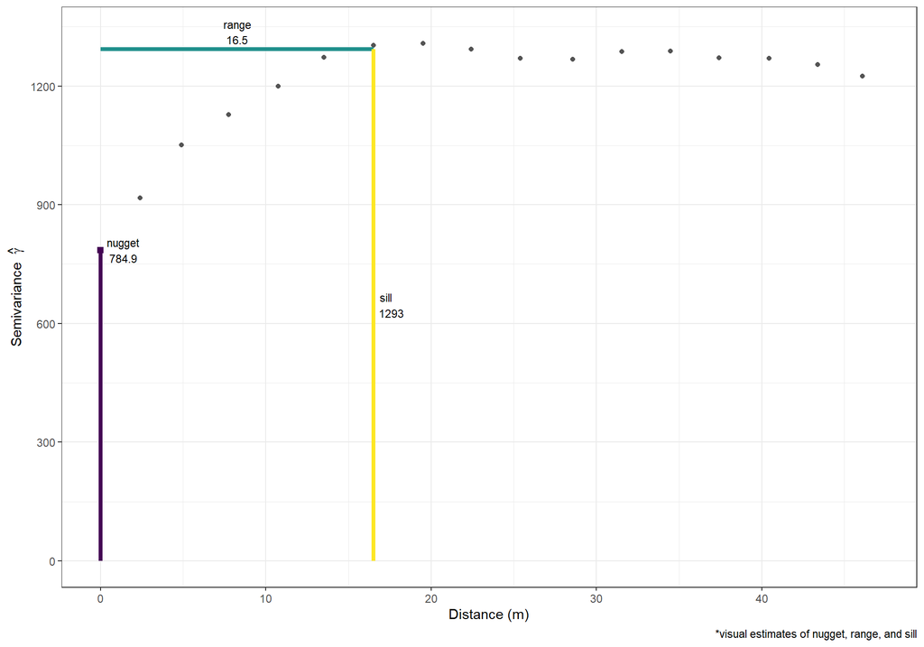

```r
gstat_veg <- cactus_df
sp::coordinates(gstat_veg) <- ~x + y
#Empirical semivariogram
empirical_gstat <- gstat::variogram(
  object = Height ~ 1
  , cutoff = maxdist
  , width = 3
  , data = gstat_veg
  ) %>%
  dplyr::arrange(dist)
# estimate nugget, sill, and range
nugget_temp <- empirical_gstat$gamma[1] -
  (empirical_gstat$gamma[2]-empirical_gstat$gamma[1])
sill_temp <- empirical_gstat %>%
    dplyr::mutate(
      pct_ch = abs((gamma - dplyr::lag(gamma, 1))/dplyr::lag(gamma, 1))
    ) %>%
    dplyr::filter(
      pct_ch <= 0.02
      & dplyr::lag(pct_ch, n = 1) <= 0.02
      & dplyr::lead(pct_ch, n = 1) <= 0.02
    ) %>%
    dplyr::filter(
      dplyr::row_number()==1
    ) %>%
    dplyr::pull(gamma)
range_temp <- empirical_gstat %>%
  dplyr::filter(
    dplyr::row_number()<which(empirical_gstat$gamma==sill_temp)
  ) %>%
  dplyr::mutate(
    pct_sill = abs((gamma - sill_temp)/sill_temp)
  ) %>%
  dplyr::arrange(
    pct_sill
  ) %>%
  dplyr::filter(
    dplyr::row_number()==1
  ) %>%
  dplyr::pull(dist)
# plot
ggplot( ) +
  geom_point(data = empirical_gstat
    , mapping = aes(x = dist, y = gamma)
    , color = "gray33", size = 1.5
  ) +
  geom_point(mapping = aes(y = nugget_temp, x = 0, color = "nugget est."), size = 2, shape = 15) +
  geom_segment(mapping = aes(
    x = 0
    , y = 0
    , xend = 0
    , yend = nugget_temp
    , color = "nugget est."), size = 1.5
  ) +
  geom_segment(mapping = aes(
    x = range_temp
    , y = sill_temp
    ,  xend = 0
    , yend = sill_temp
    , color = "range est."), size = 1.5
  ) +
  geom_segment(mapping = aes(
    x = range_temp
    , y = 0
    , xend = range_temp
    , yend = sill_temp
    , color = "sill est."), size = 1.5
  ) +
  geom_text(mapping = aes(
      y = nugget_temp, x = 0
      , label = paste("nugget\n",round(nugget_temp,1))
    )
    , hjust = -0.2
    , size = 3
  ) +
  geom_text(mapping = aes(
      y = sill_temp*1.01, x = range_temp*.5
      , label = paste0("range\n",round(range_temp,1))
    )
    , vjust = 0
    , size = 3
  ) +
  geom_text(mapping = aes(
      y = sill_temp*.5, x = range_temp
      , label = paste0(" sill\n",round(sill_temp,0))
    )
    , hjust = -0.2
    , size = 3
  ) +
  scale_y_continuous(
    limits = c(0, max(empirical_gstat$gamma)*1.02)
    , breaks = scales::extended_breaks(n=6)
  ) +
  scale_x_continuous(limits = c(0, max(empirical_gstat$dist)*1.02)) +
  scale_color_viridis_d() +
  labs(
    y = latex2exp::TeX("Semivariance  $\\hat{\\gamma}$")
    , x = "Distance (m)"
    , caption = "*visual estimates of nugget, range, and sill"
  ) +
  theme_bw() +
  theme(
    legend.position = "none"
  )
```

Based on the empirical semivariogram created using `gstat::variogram` and some “back of the napkin” math: the estimated nugget = **784.9**, the estimated range = **16.5**, and the estimated sill = **1293**.

## Question 6

Do you see any cause for concern regarding anisotropy? (3 pts)

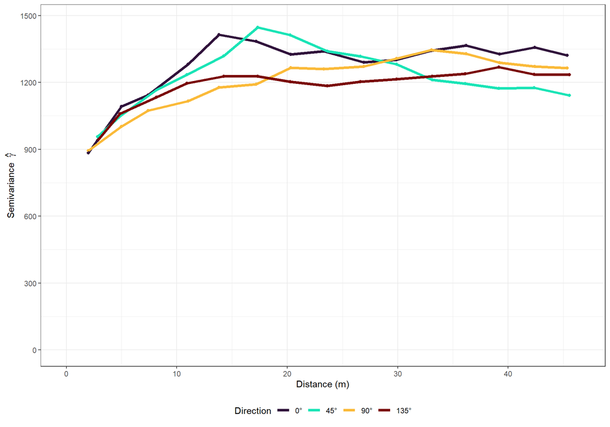

```r
#Directional variogram in gstat
empirical_gstat4 <- gstat::variogram(
    object = Height ~ 1
    , cutoff = maxdist
    , alpha = c(0,45,90,135)
    , gstat_veg
  ) %>%
  dplyr::mutate(
    dir_hor_lab = factor(
      dir.hor
      , ordered = T
      , levels = c(0,45,90,135)
      , labels = paste0(c(0,45,90,135), "\U00B0")
      )
  )
# plot
ggplot(data = empirical_gstat4
    , mapping = aes(x = dist, y = gamma, color = dir_hor_lab)
  ) +
  geom_point(size = 1.5) +
  geom_line(size = 1.5) +
  scale_y_continuous(
    limits = c(0, max(empirical_gstat4$gamma)*1.02)
    , breaks = scales::extended_breaks(n=6)
  ) +
  scale_x_continuous(limits = c(0, max(empirical_gstat4$dist)*1.02)) +
  scale_color_viridis_d(option = "turbo",name="Direction") +
  labs(
    y = latex2exp::TeX("Semivariance  $\\hat{\\gamma}$")
    , x = "Distance (m)"
  ) +
  theme_bw() +
  theme(
    legend.position = "bottom"
  ) +
  guides(
    color = guide_legend(override.aes = list(size = 5, shape = ""))
  )
```

There *does not* appear to be strong differences between the variograms calculated for different directions and, therefore, there is no strong evidence for anisotropy in this data. In the variograms above, the data are subset to create variograms calculated for the 0°, 45°, 90°, 135° directions, where 0° covers the range from -22.5° to 22.5°, 45° covers 22.5° to 67.5°, etc. Ansiotropy occurs when spatial autocorrelation varies in different directions. Strong differences in these empirical variograms would suggest that anisotropy might be occurring in the data.

## Question 7

Plot the empirical and spherical theoretical semivariogram (through gstat). Add three colored lines to denote the nugget (blue), sill (green), and range (red). See example on Canvas. (6 pts)

Hint: the variogramLine() function is useful in extracting the theoretical values.

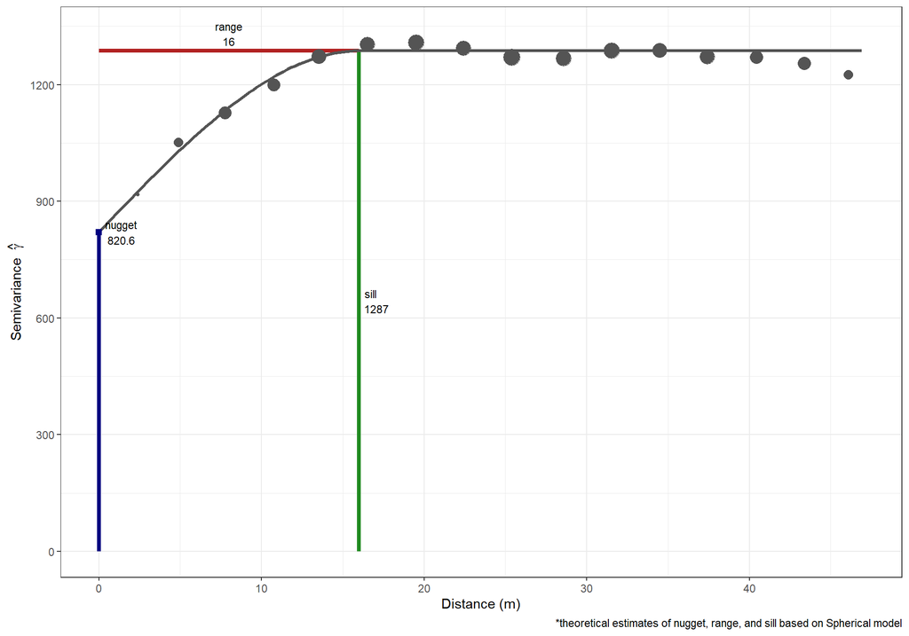

```r
#theoretical semivariogram
fit_vgram <- gstat::fit.variogram(empirical_gstat, gstat::vgm("Sph"))
theoretical_gstat <- gstat::variogramLine(fit_vgram, maxdist = maxdist)
# get the range sill and nugget
range_temp <- sum(fit_vgram$range)
nugget_temp <- fit_vgram$psill[1]
sill_temp <- sum(fit_vgram$psill)
# plot
ggplot( ) +
  geom_segment(mapping = aes(
    x = range_temp
    , y = sill_temp
    ,  xend = 0
    , yend = sill_temp
    , color = "range"), size = 1.5
  ) +
  geom_segment(mapping = aes(
    x = range_temp
    , y = 0
    , xend = range_temp
    , yend = sill_temp
    , color = "sill"), size = 1.5
  ) +
  geom_text(mapping = aes(
      y = sill_temp*1.01, x = range_temp*.5
      , label = paste0("range\n",round(range_temp,1))
    )
    , vjust = 0
    , size = 3
  ) +
  geom_text(mapping = aes(
      y = sill_temp*.5, x = range_temp
      , label = paste0(" sill\n",round(sill_temp,0))
    )
    , hjust = -0.2
    , size = 3
  ) +
  geom_point(data = empirical_gstat
    , mapping = aes(x = dist, y = gamma, size = np)
    , color = "gray33"
  ) +
  geom_line(data = theoretical_gstat
    , mapping = aes(x = dist, y = gamma)
    , color = "gray33", size = 1.2
  ) +
  geom_point(mapping = aes(y = nugget_temp, x = 0, color = "nugget"), size = 2, shape = 15) +
  geom_segment(mapping = aes(
    x = 0
    , y = 0
    , xend = 0
    , yend = nugget_temp
    , color = "nugget"), size = 1.5
  ) +
  geom_text(mapping = aes(
      y = nugget_temp, x = 0
      , label = paste("nugget\n",round(nugget_temp,1))
    )
    , hjust = -0.2
    , size = 3
  ) +
  scale_y_continuous(
    limits = c(0, max(empirical_gstat$gamma)*1.02)
    , breaks = scales::extended_breaks(n=6)
  ) +
  scale_x_continuous(limits = c(0, max(empirical_gstat$dist)*1.02)) +
  scale_color_manual(
    # nugget (blue), sill (green), and range (red)
    values = c("navy", "firebrick", "forestgreen")
  ) +
  labs(
    y = latex2exp::TeX("Semivariance  $\\hat{\\gamma}$")
    , x = "Distance (m)"
    , caption = "*theoretical estimates of nugget, range, and sill based on Spherical model"
  ) +
  theme_bw() +
  theme(
    legend.position = "none"
  )
```

Based on the theoretical semivariogram created using a Spherical model: the estimated nugget = **820.6**, the estimated range = **16**, and the estimated sill = **1287**.

## Question 8

Contrast the use of inverse distance weighting interpolation and kriging (using either spherical or exponential). Which method yields a better interpolation? A visual assessment is fine at this stage. (4 pts)

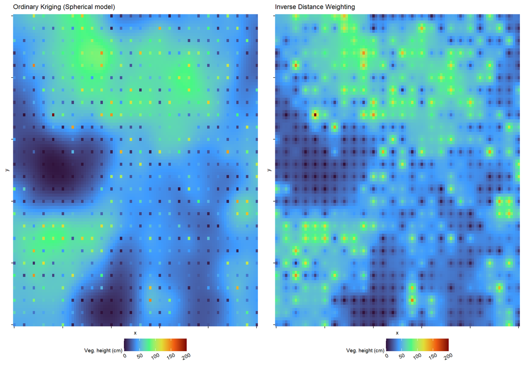

```r
grid_1m <- expand.grid(
  x = seq(from = 0, to = max(cactus_df$x), by = .5)
  , y = seq(from = 0, to = max(cactus_df$y), by = .5)
)
#convert to sp object
sp::gridded(grid_1m) = ~x + y
# ordinary kriging
krig_gstat <- gstat::krige(
   formula = Height ~ 1
   , locations = gstat_veg
   , grid_1m
   , model = fit_vgram
)
#Inverse distance weighting
idw_gstat <- gstat::idw(
  formula = Height ~ 1
  , locations = gstat_veg
  , grid_1m
)
# PLOT
plt_krig <- krig_gstat %>%
  stars::st_as_stars() %>%
  as.data.frame(xy = TRUE) %>%
  dplyr::rename(pred = 3, var = 4) %>%
ggplot(.) +
  geom_raster(mapping = aes(x=x, y=y, fill=pred)) +
  scale_fill_viridis_c(option = "turbo") +
  scale_x_continuous(expand = c(0, 0)) +
  scale_y_continuous(expand = c(0, 0)) +
  labs(
    subtitle = "Ordinary Kriging (Spherical model)"
    , x = "x"
    , y = "y"
    , fill = "Veg. height (cm)"
  ) +
  theme_bw() +
  theme(
    legend.position = "bottom"
    , legend.direction = "horizontal"
    , legend.margin = margin(0,0,0,0)
    , legend.box.margin = margin(-7,0,2,0)
    , legend.text = element_text(size = 7, angle = 25, hjust = 0.7)
    , legend.title = element_text(size = 7)
    , axis.title = element_text(size = 7)
    , axis.text.y = element_blank()
    , axis.text.x = element_blank()
    , panel.border = element_blank()
    , plot.subtitle = element_text(size=9)
  )

plt_idw <- idw_gstat %>%
  stars::st_as_stars() %>%
  as.data.frame(xy = TRUE) %>%
  dplyr::rename(pred = 3, var = 4) %>%
ggplot(.) +
  geom_raster(mapping = aes(x=x, y=y, fill=pred)) +
  scale_fill_viridis_c(option = "turbo") +
  scale_x_continuous(expand = c(0, 0)) +
  scale_y_continuous(expand = c(0, 0)) +
  labs(
    subtitle = "Inverse Distance Weighting"
    , x = "x"
    , y = "y"
    , fill = "Veg. height (cm)"
  ) +
  theme_bw() +
  theme(
    legend.position = "bottom"
    , legend.direction = "horizontal"
    , legend.margin = margin(0,0,0,0)
    , legend.box.margin = margin(-7,0,2,0)
    , legend.text = element_text(size = 7, angle = 25, hjust = 0.7)
    , legend.title = element_text(size = 7)
    , axis.title = element_text(size = 7)
    , axis.text.y = element_blank()
    , axis.text.x = element_blank()
    , panel.border = element_blank()
    , plot.subtitle = element_text(size=9)
  )

# plot
cowplot::plot_grid(
  plotlist =  list(plt_krig, plt_idw)
  , nrow = 1
)
```

As shown above, the two spatial interpolation methods — inverse distance weighting and ordinary kriging using a spherical model — provide very similar predictions of vegetation height. The ordinary kriging estimates of vegetation height feature smoother transitions between height classes compared to the inverse distance weighting estimates. The dense, regular sampling of cactus height data in this study influenced the similar results. The two approaches might exhibit less similarities in predictions given sparse and/or irregularly spaced sampling.

# Part 3: Elevation Data

## Question 9

Use the code on Lines 244 to 276 to download elevation data and prepare the raster for the following kriging exercise. First, crop the extent and aggregate with the supplied code. Next, take a random selection of 500 points from the elevation surface. Using the code and knowledge gained through this lab, use kriging to interpolate elevation across the landscape using the 500 randomly selected points. (17 pts)

### Load data

```r
########################
# load data
########################
#load elevation tif
srtm <- terra::rast("../data/srtm_15_05.tif")
e <- terra::ext(-107.5, -107, 37.5, 38)
srtm <- terra::crop(srtm, e)
# aggregate to reduce computation
srtm <- terra::aggregate(srtm, fact=10, fun=mean)
########################
# sample 500 points
########################
#extract 500 points of elevation, randomly drawn
set.seed(2020)
srtm_pts_df <- terra::spatSample(srtm, size = 500, method="random", xy=TRUE) %>%
  as.data.frame(xy=TRUE) %>%
  dplyr::rename(elevation=3) %>%
  dplyr::mutate(is_sample = 1)
# create spatial coordinates
srtm_pts_sp <- srtm_pts_df
sp::coordinates(srtm_pts_sp) <- ~x + y
########################
# create grid to interpolate elevation
########################
#Create grid with intervals of 0.008333333 degree)
e <- terra::ext(srtm)
# create raster with same extent as elev.tif then convert to df
estimation_grid <- terra::rast(e, resolution = terra::res(srtm), val = 1) %>%
  as.data.frame(xy=TRUE) %>%
  dplyr::select(x, y)
sp::gridded(estimation_grid) = ~x + y
```

### part a)

What model fits best to the empirical variogram? Which did you try?

#### Elevation Semivariance

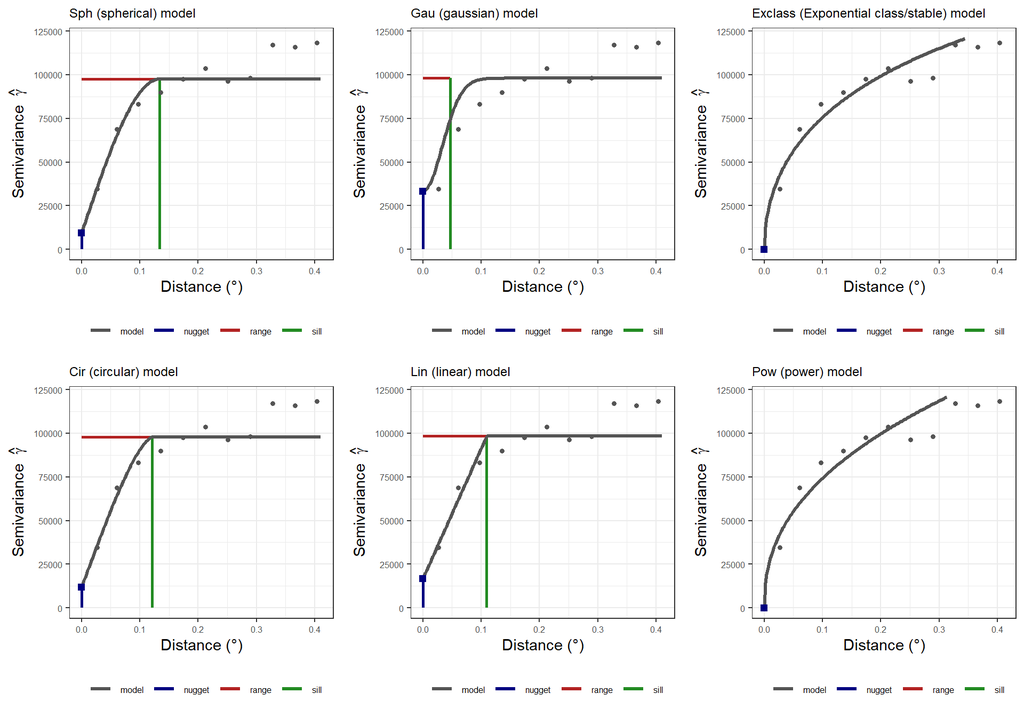

```r
#  Computes Moran's coefficients on distance classes
# pgirmess::correlog
  elev_morans <- pgirmess::correlog(
      coords = srtm_pts_df %>% dplyr::select(x, y)
      , z = srtm_pts_df$elevation
      , method = "Moran"
      , nbclass = 14
      , alternative = "two.sided"
    ) %>%
    as.data.frame() %>%
    dplyr::mutate(
      method = "pgirmess::correlog"
      , signif = ordered(
        ifelse(p.value <= 0.05, 1, 0)
        , levels = c(0, 1)
        , labels = c("p-value>0.05", "p-value<0.05")
      )
    )
#Maximum distance to consider in correlogram/variogram (~1/2 to 2/3 total dist)
  maxdist <- max(elev_morans$dist.class)*(2/3)
  # plot
  if(FALSE){
    ggplot(
        data = elev_morans %>% dplyr::filter(dist.class<maxdist)
        , mapping = aes(x = dist.class, y = coef)
      ) +
      geom_point(mapping=aes(color=signif)) +
      geom_hline(mapping = aes(yintercept=0), linetype="dashed") +
      labs(
        x = "Distance (deg.)"
        , y = "Moran's I"
      ) +
      theme_bw() +
      theme(
        legend.position = "top"
        , legend.title = element_blank()
      )

  }

#Empirical semivariogram
  empirical_semivar <- gstat::variogram(
    object = elevation ~ 1
    , cutoff = maxdist
    , width = sd(elev_morans$dist.class)*0.2
    , data = srtm_pts_sp
    ) %>%
    dplyr::arrange(dist)
  # PLOT
  # plot(empirical_semivar)
#theoretical semivariogram
plt_vgram_fn <- function(vgm_sht = "Sph") {
  fit_vgram <- gstat::fit.variogram(empirical_semivar, gstat::vgm(vgm_sht))
  theoretical_semivar <- gstat::variogramLine(fit_vgram, maxdist = maxdist)
# plot(theoretical_semivar)
# get the range sill and nugget
  range_temp <- sum(fit_vgram$range)
  nugget_temp <- fit_vgram$psill[1]
  sill_temp <- sum(fit_vgram$psill)
# plot
  plt <- ggplot( ) +
    geom_segment(mapping = aes(
      x = range_temp
      , y = sill_temp
      ,  xend = 0
      , yend = sill_temp
      , color = "range"), size = 1
    ) +
    geom_segment(mapping = aes(
      x = range_temp
      , y = 0
      , xend = range_temp
      , yend = sill_temp
      , color = "sill"), size = 1
    ) +
    geom_point(data = empirical_semivar
      , mapping = aes(x = dist, y = gamma, size = np)
      , color = "gray33"
      , size = 1.2
    ) +
    geom_line(data = theoretical_semivar
      , mapping = aes(x = dist, y = gamma, color = "model")
      , size = 1.2
    ) +
    geom_point(mapping = aes(y = nugget_temp, x = 0, color = "nugget"), size = 2, shape = 15) +
    geom_segment(mapping = aes(
      x = 0
      , y = 0
      , xend = 0
      , yend = nugget_temp
      , color = "nugget"), size = 1
    ) +
    scale_y_continuous(
      limits = c(0, max(empirical_semivar$gamma)*1.02)
      , breaks = scales::extended_breaks(n=6)
    ) +
    scale_x_continuous(limits = c(0, max(empirical_semivar$dist)*1.02)) +
    scale_color_manual(
      # nugget (blue), sill (green), and range (red)
      values = c("gray33", "navy", "firebrick", "forestgreen")
    ) +
    labs(
      y = latex2exp::TeX("Semivariance  $\\hat{\\gamma}$")
      , x = "Distance (\U00B0)"
      , subtitle = paste0(
        gstat::vgm() %>% dplyr::filter(short==vgm_sht) %>% dplyr::pull(long)
        , " model"
        )
    ) +
    theme_bw() +
    theme(
      legend.position = "bottom"
      , legend.title = element_blank()
      , axis.text = element_text(size = 6)
      , legend.text = element_text(size = 6)
      , plot.subtitle = element_text(size=9)
    ) +
    guides(
      color = guide_legend(override.aes = list(size = 5, shape = ""))
      , size = "none"
    )

  return(plt)
}
# plt_list <- c("Exp","Sph","Gau","Exc","Mat","Log","Pow","Spl") %>%
plt_list <- c("Sph","Gau", "Exc", "Cir", "Lin", "Pow") %>%
  purrr::map(plt_vgram_fn)
# combine
cowplot::plot_grid(
  plotlist = plt_list
  , nrow = 2
)
```

The figure above displays the 6 different theoretical models tested for best fit to the empirical variogram. Visual inspection shows that the Spherical model and the Circular model best fit the emperical variogram of elevation data.

### part b)

Provide the correlation between your best kriged model predictions and the known elevation.

#### Kriging and IDW estimates

```r
# use spherical model
  bestfit_vgram <- gstat::fit.variogram(empirical_semivar, gstat::vgm("Sph"))
  besttheoretical_semivar <- gstat::variogramLine(bestfit_vgram, maxdist = maxdist)
# ordinary kriging
elev_krig <- gstat::krige(
   formula = elevation ~ 1
   , locations = srtm_pts_sp
   , estimation_grid
   , model = bestfit_vgram
)
# plot(elev_krig)
#Inverse distance weighting
elev_idw <- gstat::idw(
  formula = elevation ~ 1
  , locations = srtm_pts_sp
  , estimation_grid
)
# get estimated elevation from sample points
# all points df
srtm_all_pts_df <- srtm %>%
  as.data.frame(xy = T) %>%
  dplyr::rename(elevation=3) %>%
  # remove sample points
  dplyr::left_join(
    srtm_pts_df %>% dplyr::select(x,y,is_sample)
    , by = c("x"="x", "y"="y")
  ) %>%
  dplyr::filter(is.na(is_sample)) %>%
  dplyr::select(-is_sample) %>%
  dplyr::mutate(ID=dplyr::row_number()) %>%
  # convert to sf
  sf::st_as_sf(coords = c("x", "y"), crs = terra::crs(srtm))
# join to estimated
srtm_all_pts_df <- srtm_all_pts_df %>%
  dplyr::left_join(
    terra::extract(
        elev_krig %>% stars::st_as_stars() %>% terra::rast()
        , srtm_all_pts_df %>% terra::vect()
      ) %>%
      dplyr::select(1:2) %>%
      dplyr::rename(krig_pred=2)
    , by = c("ID"="ID")
  ) %>%
  dplyr::left_join(
    terra::extract(
        elev_idw %>% stars::st_as_stars() %>% terra::rast()
        , srtm_all_pts_df %>% terra::vect()
      ) %>%
      dplyr::select(1:2) %>%
      dplyr::rename(idw_pred=2)
    , by = c("ID"="ID")
  )
```

#### Kriging Correlation

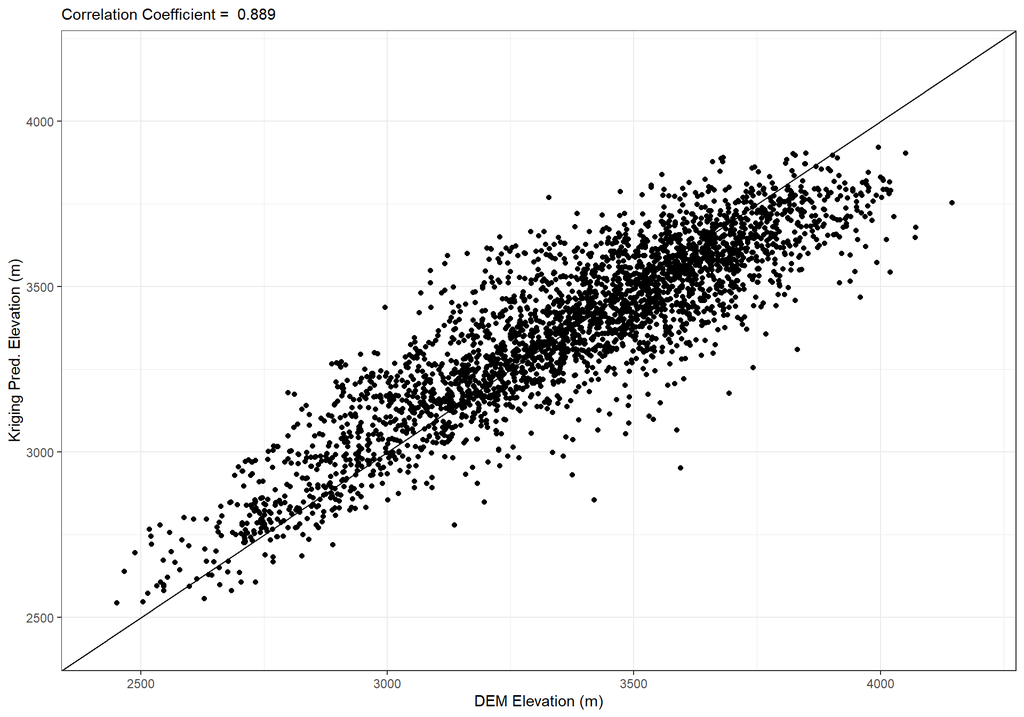

```r
# correlation
krig_corr <- stats::cor(srtm_all_pts_df$elevation, srtm_all_pts_df$krig_pred)
ggplot(data=srtm_all_pts_df) +
  geom_point(mapping = aes(x=elevation, y=krig_pred)) +
  geom_abline() +
  scale_x_continuous(limits = c(
    min(srtm_all_pts_df$elevation)*0.99
    , max(srtm_all_pts_df$elevation)*1.01
    )
  ) +
  scale_y_continuous(limits = c(
    min(srtm_all_pts_df$elevation)*0.99
    , max(srtm_all_pts_df$elevation)*1.01
    )
  ) +
  labs(
    x="DEM Elevation (m)"
    ,y="Kriging Pred. Elevation (m)"
    , subtitle = paste("Correlation Coefficient = ", round(krig_corr,3))
  ) +
  theme_bw()
```

The best fit model predictions from the kriging method has a correlation with known elevation of **0.889**.

### part c)

Does your model perform better than inverse distance weighting? Provide the correlation between inverse distance weighting predictions and the known elevation.

#### IDW Correlation

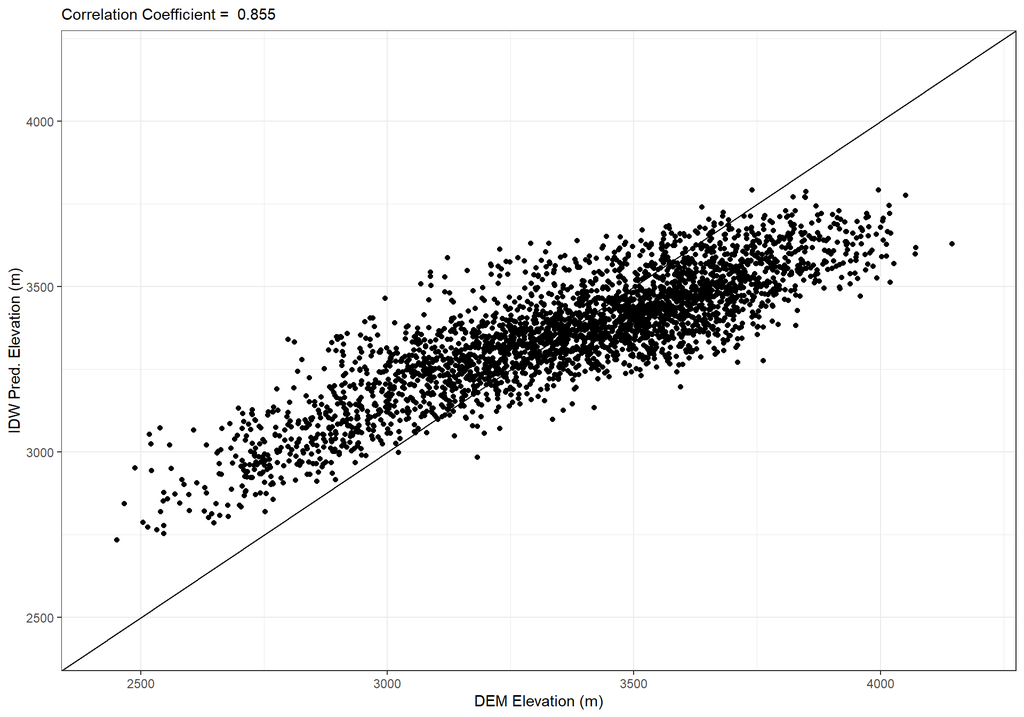

```r
# correlation
idw_corr <- stats::cor(srtm_all_pts_df$elevation, srtm_all_pts_df$idw_pred)
ggplot(data=srtm_all_pts_df) +
  geom_point(mapping = aes(x=elevation, y=idw_pred)) +
  geom_abline() +
  scale_x_continuous(limits = c(
    min(srtm_all_pts_df$elevation)*0.99
    , max(srtm_all_pts_df$elevation)*1.01
    )
  ) +
  scale_y_continuous(limits = c(
    min(srtm_all_pts_df$elevation)*0.99
    , max(srtm_all_pts_df$elevation)*1.01
    )
  ) +
  labs(
    x="DEM Elevation (m)"
    ,y="IDW Pred. Elevation (m)"
    , subtitle = paste("Correlation Coefficient = ", round(idw_corr,3))
  ) +
  theme_bw()
```

The best fit model predictions from the IDW method has a correlation with known elevation of **0.855**. The kriging estimation method performs better than the IDW method for this data.

### part d)

Make a four-panel plot that includes the randomly sampled points (shaded by elevation) and raster elevations from kriging, inverse distance weighting, and the truth. See example on Canvas. Use ggplot to generate the graphic.

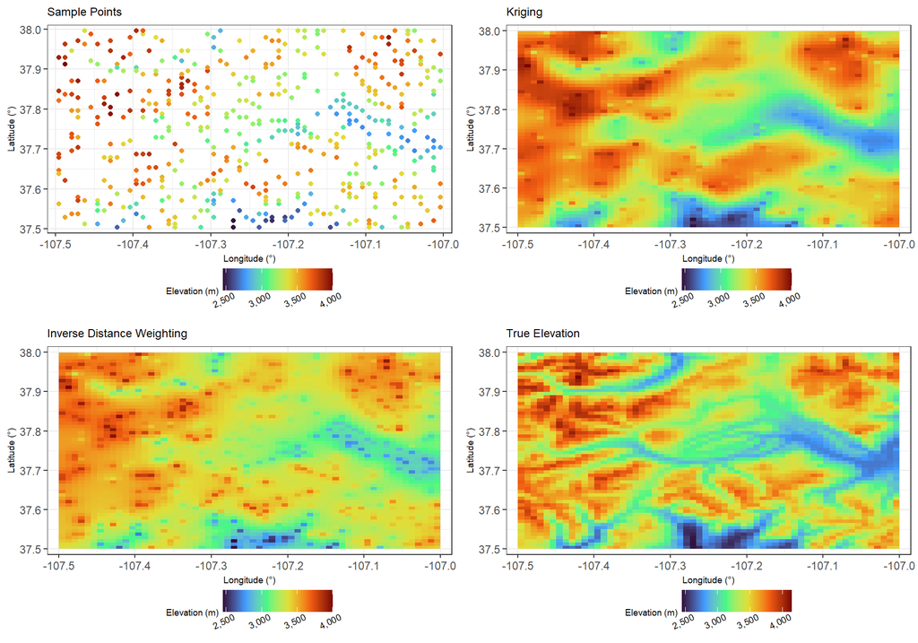

```r
# random points
plt_pts <- ggplot(data = srtm_pts_df) +
  geom_point(mapping = aes(x = x, y = y, color = elevation)) +
  scale_color_viridis_c(option = "turbo", label = scales::comma) +
  scale_x_continuous(expand = c(0.01, 0.01)) +
  scale_y_continuous(expand = c(0.01, 0.01)) +
  labs(
    x="Longitude (\U00B0)"
    ,y="Latitude (\U00B0)"
    , subtitle = "Sample Points"
    , color = "Elevation (m)"
  ) +
  theme_bw() +
  theme(
    legend.position = "bottom"
    , legend.direction = "horizontal"
    , legend.margin = margin(0,0,0,0)
    , legend.box.margin = margin(-7,0,2,0)
    , legend.text = element_text(size = 7, angle = 25, hjust = 0.7)
    , legend.title = element_text(size = 7)
    , axis.title = element_text(size = 7)
    , plot.subtitle = element_text(size=9)
  )
# idw
plt_idw <- elev_idw %>%
  stars::st_as_stars() %>%
  as.data.frame(xy = TRUE) %>%
  dplyr::rename(pred = 3, var = 4) %>%
ggplot(.) +
  geom_raster(mapping = aes(x=x, y=y, fill=pred)) +
  scale_fill_viridis_c(option = "turbo", label = scales::comma) +
  scale_x_continuous(expand = c(0.01, 0.01)) +
  scale_y_continuous(expand = c(0.01, 0.01)) +
  labs(
    x="Longitude (\U00B0)"
    ,y="Latitude (\U00B0)"
    , subtitle = "Inverse Distance Weighting"
    , fill = "Elevation (m)"
  ) +
  theme_bw() +
  theme(
    legend.position = "bottom"
    , legend.direction = "horizontal"
    , legend.margin = margin(0,0,0,0)
    , legend.box.margin = margin(-7,0,2,0)
    , legend.text = element_text(size = 7, angle = 25, hjust = 0.7)
    , legend.title = element_text(size = 7)
    , axis.title = element_text(size = 7)
    , plot.subtitle = element_text(size=9)
  )
# krig
plt_krig <- elev_krig %>%
  stars::st_as_stars() %>%
  as.data.frame(xy = TRUE) %>%
  dplyr::rename(pred = 3, var = 4) %>%
ggplot(.) +
  geom_raster(mapping = aes(x=x, y=y, fill=pred)) +
  scale_fill_viridis_c(option = "turbo", label = scales::comma) +
  scale_x_continuous(expand = c(0.01, 0.01)) +
  scale_y_continuous(expand = c(0.01, 0.01)) +
  labs(
    x="Longitude (\U00B0)"
    ,y="Latitude (\U00B0)"
    , subtitle = "Kriging"
    , fill = "Elevation (m)"
  ) +
  theme_bw() +
  theme(
    legend.position = "bottom"
    , legend.direction = "horizontal"
    , legend.margin = margin(0,0,0,0)
    , legend.box.margin = margin(-7,0,2,0)
    , legend.text = element_text(size = 7, angle = 25, hjust = 0.7)
    , legend.title = element_text(size = 7)
    , axis.title = element_text(size = 7)
    , plot.subtitle = element_text(size=9)
  )
# krig
plt_real <- srtm %>%
  stars::st_as_stars() %>%
  as.data.frame(xy = TRUE) %>%
  dplyr::rename(pred = 3) %>%
ggplot(.) +
  geom_raster(mapping = aes(x=x, y=y, fill=pred)) +
  scale_fill_viridis_c(option = "turbo", label = scales::comma) +
  scale_x_continuous(expand = c(0.01, 0.01)) +
  scale_y_continuous(expand = c(0.01, 0.01)) +
  labs(
    x="Longitude (\U00B0)"
    ,y="Latitude (\U00B0)"
    , subtitle = "True Elevation"
    , fill = "Elevation (m)"
  ) +
  theme_bw() +
  theme(
    legend.position = "bottom"
    , legend.direction = "horizontal"
    , legend.margin = margin(0,0,0,0)
    , legend.box.margin = margin(-7,0,2,0)
    , legend.text = element_text(size = 7, angle = 25, hjust = 0.7)
    , legend.title = element_text(size = 7)
    , axis.title = element_text(size = 7)
    , plot.subtitle = element_text(size=9)
  )

# plot
cowplot::plot_grid(
  plotlist = list(plt_pts, plt_krig, plt_idw, plt_real)
  , nrow = 2
)
```

```r
library(mapview) #Interactive maps
library(leafpop) #map html popup
library(USAboundaries)
# basemap option
mapview::mapviewOptions(homebutton = FALSE, basemaps = c("Esri.WorldImagery"))
# mapview::mapviewOptions(homebutton = FALSE, basemaps = c("USGS.USImagery"))
# map
forests_temp <- USAboundaries::us_states(states = c("CO"))
mapview::mapview(forests_temp
        , color = "black"
        , lwd = 2
        , alpha.regions = 0
        , label = FALSE
        , legend = FALSE
        , layer.name = "USFS Forests"
  )
```

[interactive chart not shown]